# Notebook 09 – Solutions

## Getting Started

Before running this notebook, select “Session > Restart R and Clear Output” in the menu above to start a new R session. This will clear any old data sets and give us a blank slate to start with.

After starting a new session, run the following code chunk to load the libraries and data that we will be working with today.

I have set the options `include=FALSE` and `message=FALSE` to avoid cluttering the solutions with all the output from this code.

## Flights

### Datasets

In this notebook we are going to work with a number of different data tables concerning commercial flights that departed from Richmond International Airport (RIC) in 2019. The data are in five different tables that can be joined together using different sets of keys. I think most of the variables are self-explanatory, but please ask if you have any questions! There is a table of airlines:

```r
airlines <- read_csv("../data/flightsrva_airlines.csv.gz")
airlines
```

```
## # A tibble: 14 × 2
##    carrier name
##    <chr>   <chr>
##  1 9E      Endeavor Air Inc.
##  2 AA      American Airlines Inc.
##  3 B6      JetBlue Airways
##  4 DL      Delta Air Lines Inc.
##  5 EV      ExpressJet Airlines LLC d/b/a aha!
##  6 G4      Allegiant Air
##  7 MQ      Envoy Air
##  8 NK      Spirit Air Lines
##  9 OH      PSA Airlines Inc.
## 10 OO      SkyWest Airlines Inc.
## 11 UA      United Air Lines Inc.
## 12 WN      Southwest Airlines Co.
## 13 YV      Mesa Airlines Inc.
## 14 YX      Republic Airline
```

One of airports:

```r
airports <- read_csv("../data/flightsrva_airports.csv.gz")
airports
```

```
## # A tibble: 1,251 × 8
##    faa   name                             lat    lon   alt    tz dst   tzone
##    <chr> <chr>                          <dbl>  <dbl> <dbl> <dbl> <chr> <chr>
##  1 AAF   Apalachicola Regional Airport   29.7  -85.0    20    -5 A     Amer…
##  2 AAP   Andrau Airpark                  29.7  -95.6    79    -6 A     Amer…
##  3 ABE   Lehigh Valley International A…  40.7  -75.4   393    -5 A     Amer…
##  4 ABI   Abilene Regional Airport        32.4  -99.7  1791    -6 A     Amer…
##  5 ABL   Ambler Airport                  67.1 -158.    334    -9 A     Amer…
##  6 ABQ   Albuquerque International Sun…  35.0 -107.   5355    -7 A     Amer…
##  7 ABR   Aberdeen Regional Airport       45.4  -98.4  1302    -6 A     Amer…
##  8 ABY   Southwest Georgia Regional Ai…  31.5  -84.2   197    -5 A     Amer…
##  9 ACK   Nantucket Memorial Airport      41.3  -70.1    47    -5 A     Amer…
## 10 ACT   Waco Regional Airport           31.6  -97.2   516    -6 A     Amer…
## # ℹ 1,241 more rows
```

The table of flights:

```r
flights <- read_csv("../data/flightsrva_flights.csv.gz") |>
  select(-time_hour) # removing for now until we discuss datetime objects
flights
```

```
## # A tibble: 24,808 × 18
##     year month   day dep_time sched_dep_time dep_delay arr_time
##    <dbl> <dbl> <dbl>    <dbl>          <dbl>     <dbl>    <dbl>
##  1  2019     1     1      548            550        -2      728
##  2  2019     1     1      552            600        -8      814
##  3  2019     1     1      558            600        -2      817
##  4  2019     1     1      630            630         0      713
##  5  2019     1     1      639            645        -6      748
##  6  2019     1     1      641            645        -4      827
##  7  2019     1     1      648            654        -6      910
##  8  2019     1     1      655            700        -5      933
##  9  2019     1     1      717            725        -8      828
## 10  2019     1     1      734            730         4      903
## # ℹ 24,798 more rows
## # ℹ 11 more variables: sched_arr_time <dbl>, arr_delay <dbl>,
## #   carrier <chr>, flight <dbl>, tailnum <chr>, origin <chr>, dest <chr>,
## #   air_time <dbl>, distance <dbl>, hour <dbl>, minute <dbl>
```

A table of planes:

```r
planes <- read_csv("../data/flightsrva_planes.csv.gz")
planes
```

```
## # A tibble: 3,120 × 9
##    tailnum  year type          manufacturer model engines seats speed engine
##    <chr>   <dbl> <chr>         <chr>        <chr>   <dbl> <dbl> <dbl> <chr>
##  1 N101HQ   2007 Fixed wing m… EMBRAER-EMP… ERJ …       2    80     0 Turbo…
##  2 N102HQ   2007 Fixed wing m… EMBRAER-EMP… ERJ …       2    80     0 Turbo…
##  3 N102UW   1998 Fixed wing m… AIRBUS INDU… A320…       2   182     0 Turbo…
##  4 N103HQ   2007 Fixed wing m… EMBRAER-EMP… ERJ …       2    80     0 Turbo…
##  5 N103SY   2014 Fixed wing m… EMBRAER S A  ERJ …       2    88     0 Turbo…
##  6 N103US   1999 Fixed wing m… AIRBUS INDU… A320…       2   182     0 Turbo…
##  7 N104HQ   2007 Fixed wing m… EMBRAER-EMP… ERJ …       2    80     0 Turbo…
##  8 N104UW   1999 Fixed wing m… AIRBUS INDU… A320…       2   182     0 Turbo…
##  9 N10575   2002 Fixed wing m… EMBRAER      EMB-…       2    55     0 Turbo…
## 10 N105HQ   2007 Fixed wing m… EMBRAER      ERJ …       2    88     0 Turbo…
## # ℹ 3,110 more rows
```

And a table of weather:

```r
weather <- read_csv("../data/flightsrva_weather.csv.gz") |>
  select(-time_hour) # removing for now until we discuss datetime objects
weather
```

```
## # A tibble: 8,735 × 14
##    origin  year month   day  hour  temp  dewp humid wind_dir wind_speed
##    <chr>  <dbl> <dbl> <dbl> <dbl> <dbl> <dbl> <dbl>    <dbl>      <dbl>
##  1 RIC     2019     1     1     0    NA    NA    NA      180       8.06
##  2 RIC     2019     1     1     1    NA    NA    NA      180      12.7
##  3 RIC     2019     1     1     2    NA    NA    NA      180      13.8
##  4 RIC     2019     1     1     3    NA    NA    NA      180      13.8
##  5 RIC     2019     1     1     4    NA    NA    NA      190      12.7
##  6 RIC     2019     1     1     5    NA    NA    NA      200      19.6
##  7 RIC     2019     1     1     6    NA    NA    NA      200      17.3
##  8 RIC     2019     1     1     7    NA    NA    NA      210      18.4
##  9 RIC     2019     1     1     8    NA    NA    NA      220      16.1
## 10 RIC     2019     1     1     9    NA    NA    NA      210      16.1
## # ℹ 8,725 more rows
## # ℹ 4 more variables: wind_gust <dbl>, precip <dbl>, pressure <dbl>,
## #   visib <dbl>
```

Before you proceed, take a moment to determine what (if any) is the primary key of each table.

### Carriers

In the first question, create a barplot showing the number of flights each carrier made in 2019 out of RIC. Order the barplot in descending order of the count of flights. Put the count on the x-axis and the airline on the y-axis.

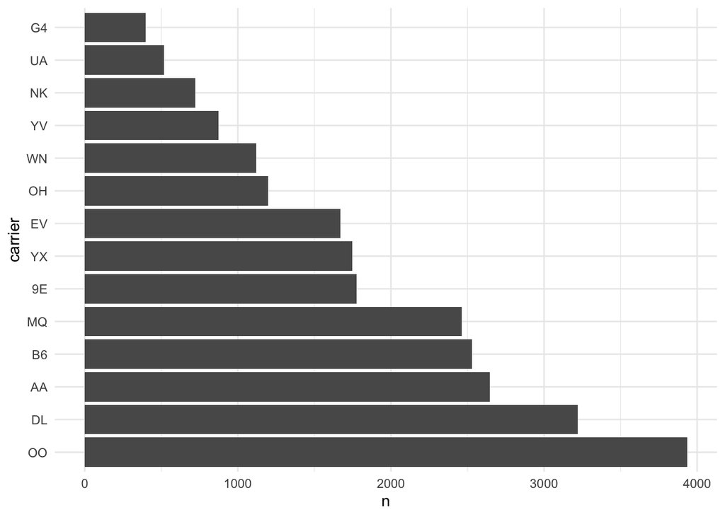

```r
# Question 01
flights |>
  group_by(carrier) |>
  summarize(n = n()) |>
  arrange(desc(n)) |>
  mutate(carrier = fct_inorder(carrier)) |>
  ggplot(aes(n, carrier)) +
    geom_col()
```

The plot above is tricky because you probably do not know all of the airline codes. Repeat the plot in the code below, but use a `left_join` to combine the results with the `airlines` dataset and use the full airline names on the y-axis rather than single codes. Do you recognize the carrier with the most flights out of the city?

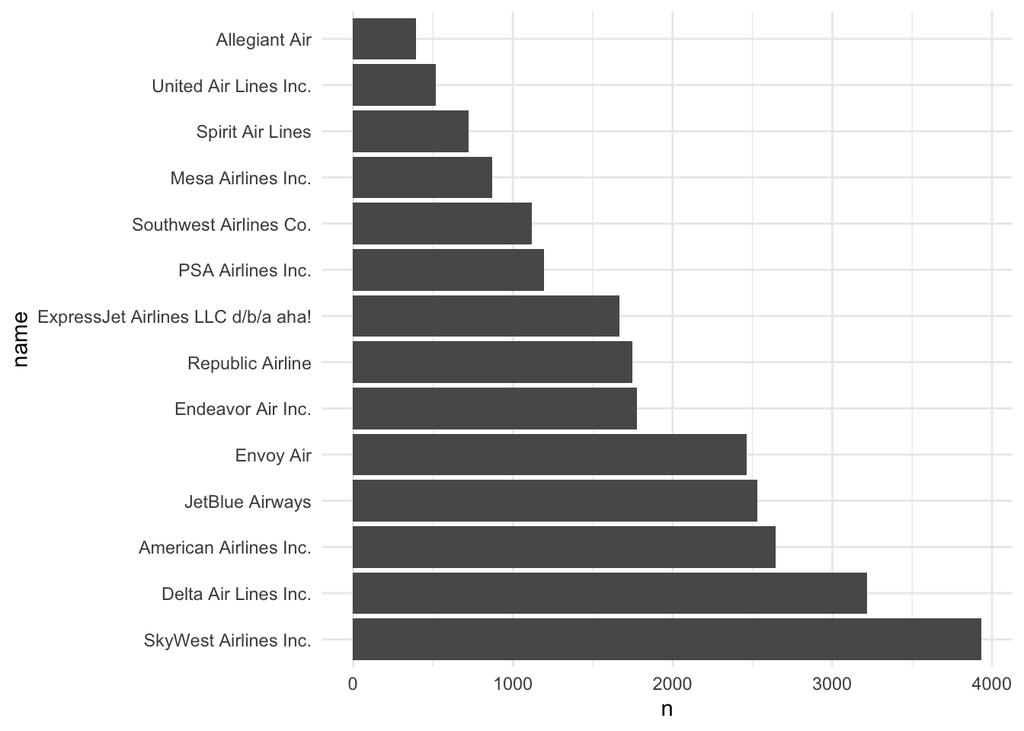

```r
# Question 02
flights |>
  group_by(carrier) |>
  summarize(n = n()) |>
  arrange(desc(n)) |>
  left_join(airlines, by = "carrier") |>
  mutate(name = fct_inorder(name)) |>
  ggplot(aes(n, name)) +
    geom_col()
```

### Destinations

Now, produce a similar barplot counting the number of outbound flights from RIC based on where the flight was going to. Put the destination code on the y-axis, counts on the x-axis, and order in descending order of count.

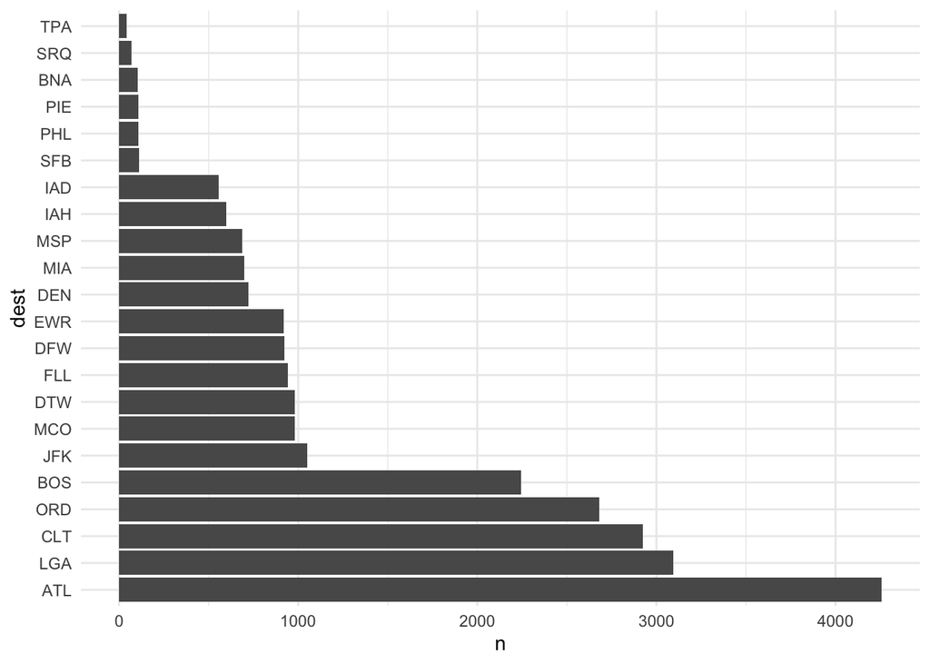

```r
# Question 03
flights |>
  group_by(dest) |>
  summarize(n = n()) |>
  arrange(desc(n)) |>
  mutate(dest = fct_inorder(dest)) |>
  ggplot(aes(n, dest)) +
    geom_col()
```

Airport codes are a bit easier to figure out that airline codes, but you probably still only know the top few from the previous plot. Modify your plot above in the code below by joining with the `airports` data and using the full airport names. Be careful with this; it is slightly more difficult than the join you did in question 2.

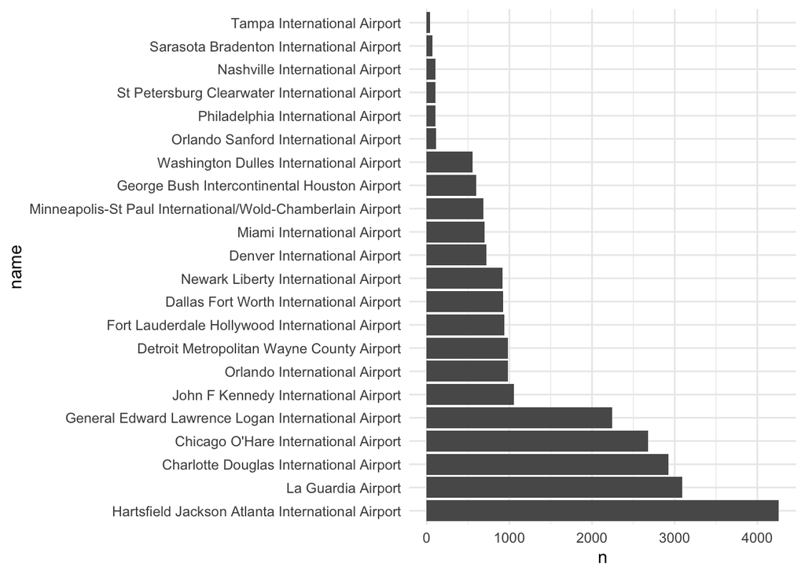

```r
# Question 04
flights |>
  group_by(dest) |>
  summarize(n = n()) |>
  arrange(desc(n)) |>
  left_join(airports, by = c("dest" = "faa")) |>
  mutate(name = fct_inorder(name)) |>
  ggplot(aes(n, name)) +
    geom_col()
```

The `airports` table has longitude and latitude in addition to the airport names. Let’s create a plot with longitude on the x-axis, latitude on the y-axis, and a point for each airport that had outbound flights from RIC in 2019. Make the size of the points scale with the number of flights and add text labels to give the airport FAA code for each city. Finally, add proper labels to the aesthetics and a title.

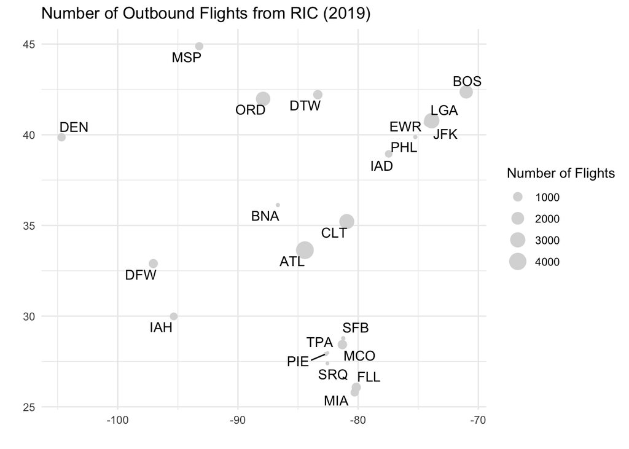

```r
# Question 05
flights |>
  group_by(dest) |>
  summarize(n = n()) |>
  arrange(desc(n)) |>
  left_join(airports, by = c("dest" = "faa")) |>
  mutate(name = fct_inorder(name)) |>
  ggplot(aes(lon, lat)) +
    geom_point(aes(size = n), color = "grey85") +
    geom_text_repel(aes(label = dest)) +
    scale_size_area() +
    labs(x = "", y = "", size = "Number of Flights",
         title = "Number of Outbound Flights from RIC (2019)")
```

Let’s add one more element to the plot above. In the code below, modify the previous plot by including a large red dot showing RIC airport.

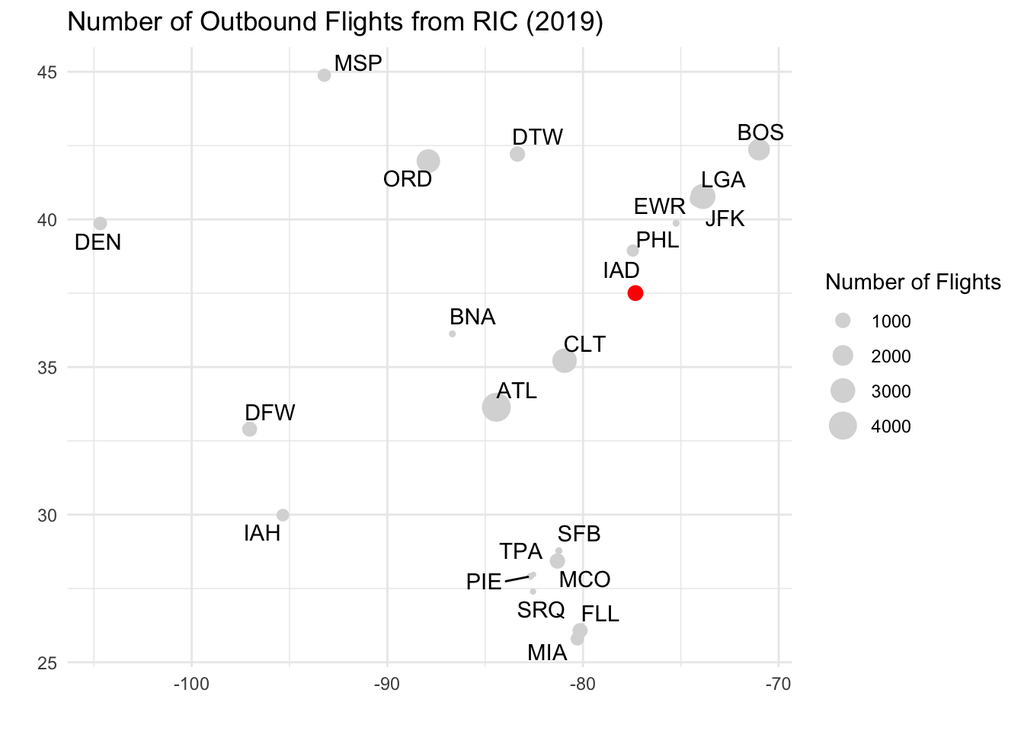

```r
# Question 06
ric <- airports |>
  filter(faa == "RIC")

flights |>
  group_by(dest) |>
  summarize(n = n()) |>
  arrange(desc(n)) |>
  left_join(airports, by = c("dest" = "faa")) |>
  mutate(name = fct_inorder(name)) |>
  ggplot(aes(lon, lat)) +
    geom_point(aes(size = n), color = "grey85") +
    geom_text_repel(aes(label = dest)) +
    geom_point(data = ric, color = "red", size = 3) +
    scale_size_area() +
    labs(x = "", y = "", size = "Number of Flights",
         title = "Number of Outbound Flights from RIC (2019)")
```

### Planes

Take the `flights` table and join to the `planes` table using the key `tailnum`. Look at the resulting data, in particular the name of the first column in the output, comparing it to the name in the first column of the original `flights` table.

```r
# Question 07
flights |>
  left_join(planes, by = "tailnum")
```

```
## # A tibble: 24,808 × 26
##    year.x month   day dep_time sched_dep_time dep_delay arr_time
##     <dbl> <dbl> <dbl>    <dbl>          <dbl>     <dbl>    <dbl>
##  1   2019     1     1      548            550        -2      728
##  2   2019     1     1      552            600        -8      814
##  3   2019     1     1      558            600        -2      817
##  4   2019     1     1      630            630         0      713
##  5   2019     1     1      639            645        -6      748
##  6   2019     1     1      641            645        -4      827
##  7   2019     1     1      648            654        -6      910
##  8   2019     1     1      655            700        -5      933
##  9   2019     1     1      717            725        -8      828
## 10   2019     1     1      734            730         4      903
## # ℹ 24,798 more rows
## # ℹ 19 more variables: sched_arr_time <dbl>, arr_delay <dbl>,
## #   carrier <chr>, flight <dbl>, tailnum <chr>, origin <chr>, dest <chr>,
## #   air_time <dbl>, distance <dbl>, hour <dbl>, minute <dbl>, year.y <dbl>,
## #   type <chr>, manufacturer <chr>, model <chr>, engines <dbl>,
## #   seats <dbl>, speed <dbl>, engine <chr>
```

Both `flights` and `planes` have a column called `year`, but they mean different things. On the first table it is the year of the flight and on second table it is the year the plane was built. Repeat the last question but add the option `suffix = c("", "_plane")` to the join function. Look at the new column names and see how this solved the problem.

```r
# Question 08
flights |>
  left_join(planes, by = "tailnum", suffix = c("", "_plane"))
```

```
## # A tibble: 24,808 × 26
##     year month   day dep_time sched_dep_time dep_delay arr_time
##    <dbl> <dbl> <dbl>    <dbl>          <dbl>     <dbl>    <dbl>
##  1  2019     1     1      548            550        -2      728
##  2  2019     1     1      552            600        -8      814
##  3  2019     1     1      558            600        -2      817
##  4  2019     1     1      630            630         0      713
##  5  2019     1     1      639            645        -6      748
##  6  2019     1     1      641            645        -4      827
##  7  2019     1     1      648            654        -6      910
##  8  2019     1     1      655            700        -5      933
##  9  2019     1     1      717            725        -8      828
## 10  2019     1     1      734            730         4      903
## # ℹ 24,798 more rows
## # ℹ 19 more variables: sched_arr_time <dbl>, arr_delay <dbl>,
## #   carrier <chr>, flight <dbl>, tailnum <chr>, origin <chr>, dest <chr>,
## #   air_time <dbl>, distance <dbl>, hour <dbl>, minute <dbl>,
## #   year_plane <dbl>, type <chr>, manufacturer <chr>, model <chr>,
## #   engines <dbl>, seats <dbl>, speed <dbl>, engine <chr>
```

Using the join code you had above, create a bar plot showing the number of flights departing from RIC based on the model year of the plane. Put the years on the x-axis and DO NOT order by frequency (we want the years in their temporal order). See any patterns?

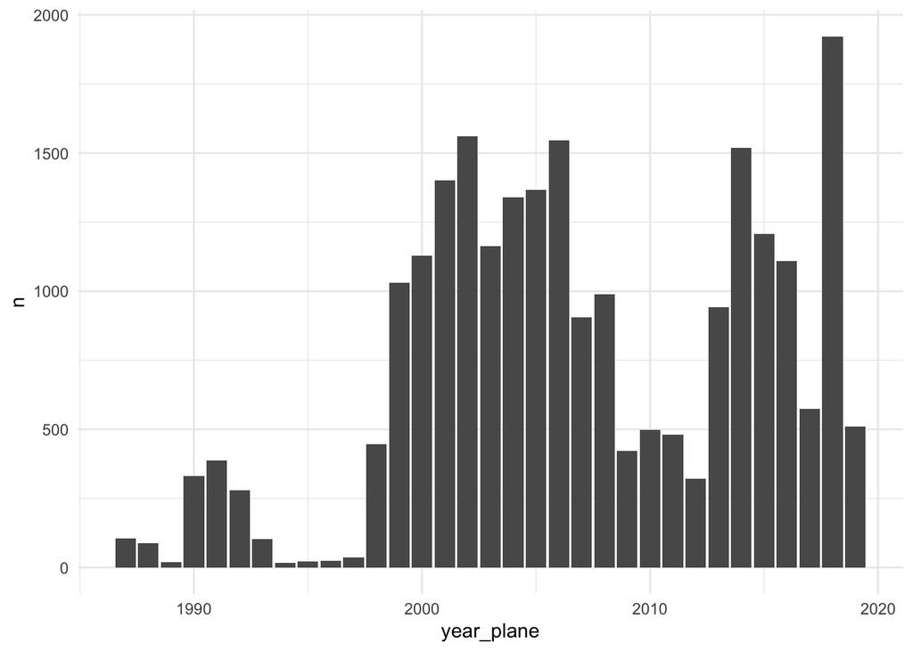

```r
# Question 09
flights |>
  left_join(planes, by = "tailnum", suffix = c("", "_plane")) |>
  group_by(year_plane) |>
  summarize(n = n()) |>
  ggplot(aes(year_plane, n)) +
    geom_col()
```

### Weather

In the code below, join together the `flight` and `weather` tables. Note that this will require a large number of features to properly define the join.

```r
# Question 10
flights |>
  left_join(weather, by = c("year", "month", "day", "hour", "origin"))
```

```
## # A tibble: 24,808 × 27
##     year month   day dep_time sched_dep_time dep_delay arr_time
##    <dbl> <dbl> <dbl>    <dbl>          <dbl>     <dbl>    <dbl>
##  1  2019     1     1      548            550        -2      728
##  2  2019     1     1      552            600        -8      814
##  3  2019     1     1      558            600        -2      817
##  4  2019     1     1      630            630         0      713
##  5  2019     1     1      639            645        -6      748
##  6  2019     1     1      641            645        -4      827
##  7  2019     1     1      648            654        -6      910
##  8  2019     1     1      655            700        -5      933
##  9  2019     1     1      717            725        -8      828
## 10  2019     1     1      734            730         4      903
## # ℹ 24,798 more rows
## # ℹ 20 more variables: sched_arr_time <dbl>, arr_delay <dbl>,
## #   carrier <chr>, flight <dbl>, tailnum <chr>, origin <chr>, dest <chr>,
## #   air_time <dbl>, distance <dbl>, hour <dbl>, minute <dbl>, temp <dbl>,
## #   dewp <dbl>, humid <dbl>, wind_dir <dbl>, wind_speed <dbl>,
## #   wind_gust <dbl>, precip <dbl>, pressure <dbl>, visib <dbl>
```

The function `cut` takes two arguments, a numeric feature and an integer number of buckets. It converts a number value into a set of ordered categories by bucketing the numeric values into equally spaced bins. In the next question, join the `flights` and `weather` tables together, and create a new variable that cuts the `wind_gust` feature into 10 buckets. Take a moment to look at and understand the output.

```r
# Question 11
flights |>
  left_join(weather, by = c("year", "month", "day", "hour", "origin")) |>
  mutate(wind_gust_cat = cut(wind_gust, 10))
```

```
## # A tibble: 24,808 × 28
##     year month   day dep_time sched_dep_time dep_delay arr_time
##    <dbl> <dbl> <dbl>    <dbl>          <dbl>     <dbl>    <dbl>
##  1  2019     1     1      548            550        -2      728
##  2  2019     1     1      552            600        -8      814
##  3  2019     1     1      558            600        -2      817
##  4  2019     1     1      630            630         0      713
##  5  2019     1     1      639            645        -6      748
##  6  2019     1     1      641            645        -4      827
##  7  2019     1     1      648            654        -6      910
##  8  2019     1     1      655            700        -5      933
##  9  2019     1     1      717            725        -8      828
## 10  2019     1     1      734            730         4      903
## # ℹ 24,798 more rows
## # ℹ 21 more variables: sched_arr_time <dbl>, arr_delay <dbl>,
## #   carrier <chr>, flight <dbl>, tailnum <chr>, origin <chr>, dest <chr>,
## #   air_time <dbl>, distance <dbl>, hour <dbl>, minute <dbl>, temp <dbl>,
## #   dewp <dbl>, humid <dbl>, wind_dir <dbl>, wind_speed <dbl>,
## #   wind_gust <dbl>, precip <dbl>, pressure <dbl>, visib <dbl>,
## #   wind_gust_cat <fct>
```

Starting with the code you had above, group the data but the wind gust buckets, compute the average delay of flights within each category, and compute the number of flights in each bucket. You will need to remove missing values in the `mean` function. Produce a scatter plot that shows the average delay on the x-axis, the wind category on the y-axis, and use the size of the points to indicate the number of flights.

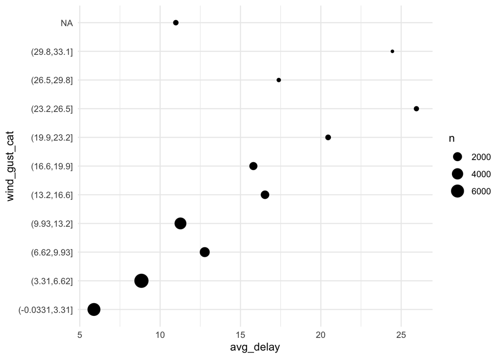

```r
# Question 12
flights |>
  left_join(weather, by = c("year", "month", "day", "hour", "origin")) |>
  mutate(wind_gust_cat = cut(wind_gust, 10)) |>
  group_by(wind_gust_cat) |>
  summarize(avg_delay = mean(dep_delay, na.rm = TRUE), n = n()) |>
    ggplot(aes(avg_delay, wind_gust_cat)) +
      geom_point(aes(size = n))
```

Does there appear to be a relationship between high wind speeds and departure delays?

### Big Planes

To finish, let’s see how we can make use of a filter join. Create a table in the code below called `big_planes` that only contains the rows of `planes` with more than 200 seats.

```r
# Question 13
big_planes <- planes |>
  filter(seats > 200)
```

Repeat the code you had for question 4, but use a filter join to only include flights that have greater than 200 seats.

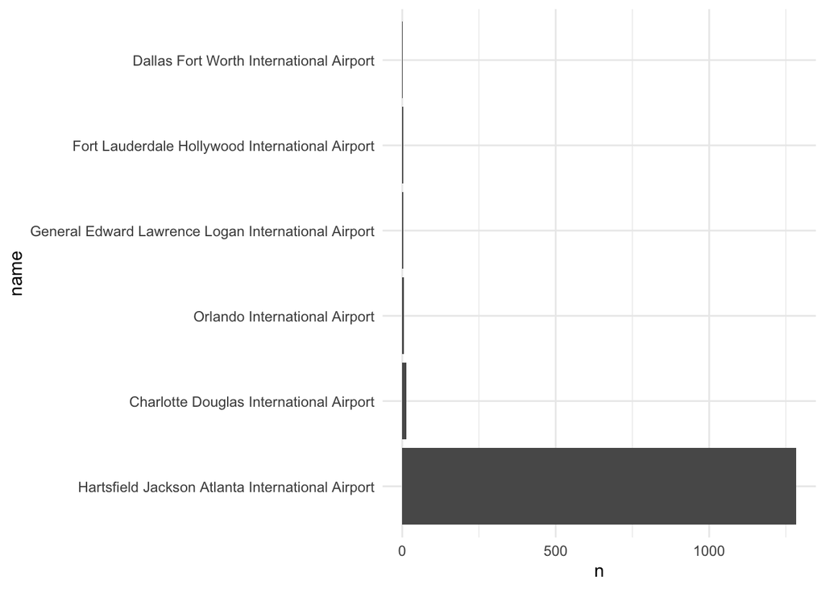

```r
# Question 14
flights |>
  semi_join(big_planes, by = "tailnum") |>
  group_by(dest) |>
  summarize(n = n()) |>
  arrange(desc(n)) |>
  left_join(airports, by = c("dest" = "faa")) |>
  mutate(name = fct_inorder(name)) |>
  ggplot(aes(n, name)) +
    geom_col()
```

Where are all of the big planes going that depart from RIC? **Answer**: Nearly every larger plane in the datset is going to Atlanta.